# Ch10 Advanced Topics in Pricing

Jing Fang

# Ch10 Advanced Topics in Pricing

- This chapter analyzes more complicated methods of price discrimination than were discussed in Chapter 9, such as nonlinear pricing, two-part tariffs, quantity discounts, tie-in sales, and quality choice.
- The key points of this chapter are:

# Ch10 Advanced Topics in Pricing

1. Nonlinear pricing schemes can be used by a firm to price discriminate when the firm does not know the demands of individual consumers.
2. A firm can induce consumers to reveal which group they belong to through their choice from among several two-part tariffs.
3. The effectiveness of tie-in sales in increasing profits depends on whether demands for these goods are related.
4. A firm with market power may use a variety of other policies to increase its profit above what it would earn if it charged everyone the same price.

# Nonlinear Pricing

# Nonlinear Pricing

- **Nonlinear pricing** occurs when a consumer’s total expenditure on an item does not rise linearly with the amount purchased.
- A firm that uses a two-part tariff charges consumers a lump-sum fee for the right to purchase goods and a usage charge per unit.

# Nonlinear Pricing

- When a two-part tariff is used, a firm must somehow prevent resale.
- When consumers are identical, a two-part tariff can be used to extract all CS.
- We assume that the firm knows that demands differ within the population but lacks specific knowledge of each individual consumer’s demand.

# Nonlinear Pricing

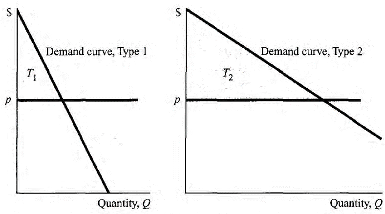

# Nonlinear Pricing

- The optimal two-part tariff typically generates more profits than a single price, because a single price is a special type of a two-part tariff: a two-part tariff with a zero lump-sum fee.
- One can think of a two-part tariff as consisting of a fixed charge for one product and a marginal charge for another.

# Nonlinear Pricing

- The two-part tariff just described is one of the simplest examples of a pricing structure in which the average price varies with output—which is a characteristic of any nonlinear pricing scheme.
- Finding the general nonlinear pricing policy that maximizes a monopoly’s profits is complicated.

# Nonlinear Pricing

- Suppose a firm knows the demand curves of two types of consumers and the prevalence of different types of consumers in the population, but it does not know the type of any individual consumer.
- The firm can offer consumers a choice of two different two-part tariff schedules.
- Each consumer chooses or self-selects that schedule that corresponds to a higher level of utility.

# Nonlinear Pricing

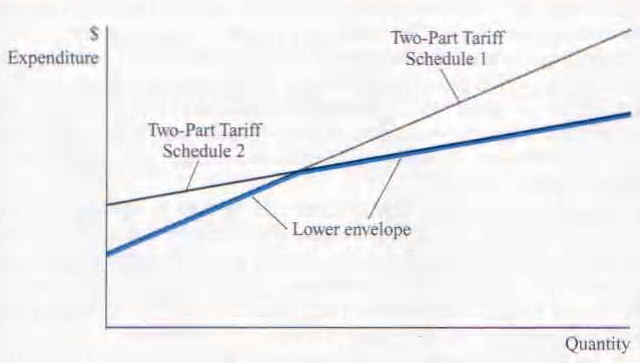

# Nonlinear Pricing

- The firm chooses its two two-part tariff schedules to maximize the profits.
- If the firm knew which consumers belonged to each group and could prevent resale, the firm could design a two-part tariff for each group.
- The optimal policy is for the firm to charge each consumer a price equal its MC, m, and to extract the CS of each consumer by charging a lump-sum fee.

# Nonlinear Pricing

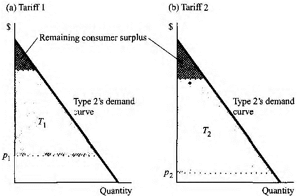

# Nonlinear Pricing

- Type 2 consumers benefit from the presence of the Type 1 consumers.
- Without the Type 1 consumers, Type 2 consumers would receive zero utility.

# Nonlinear Pricing with an Example

- With nonlinear pricing, consumer i faces the following problem: $\begin{matrix} \max_{q_i,y_i} & u_i(q_i,y_i) \\ s.t. & E(q_i)+y_i=I_i \end{matrix}$
- The maximization problem facing a firm that wishes to offer a nonlinear pricing schedule that maximizes its profit is to choose E() to maximize $\sum_i[E(q_i)-mq_i]$

# Nonlinear Pricing with an Example

- The firm chooses the E(q) to maximize profits, which equals the sum of the profits made by selling to each consumer, subject to the condition that each consumer maximizes his or her utility.
- The solution to the problem posed in previous equation is complicated (Katz 1983; Spence 1977b; Tirole 1988, Ch. 3).

# Nonlinear Pricing with an Example

- Consider the simple problem discussed in the chapter of a firm that faces two consumers, 1 and 2, and offers two two-part tariff ($T_1, p_1$) and ($T_2, p_2$).
- Then profit equals: $T_1+(p_1-m)q_1(p_1)+T_2+(p_2-m)q_2(p_2)$
- The self-selection constraints are: $\begin{matrix} U_1(T_1,p_1) & \geq & U_1(T_2,p_2) \\ U_2(T_1,p_1) & \leq & U_2(T_2,p_2) \end{matrix}$

# Nonlinear Pricing with an Example

- Let $S_i(p)$ be the CS of consumer i at price p in the absence of a lump-sum fee T.
- Then utility can be written as $U_i(T,p)=S_i(p)-T$
- The pricing problem facing the firm is: $\begin{matrix} \max_{T_1,p_1,T_2,p_2} & T_1+(p_1-m)q_1(p_1)+T_2+(p_2-m)q_2(p_2) \\ s.t. & \begin{matrix} S_1(p_1)-T_1 & \geq & S_1(p_2)-T_2 \\ S_2(p_1)-T_1 & \leq & S_2(p_2)-T_2 \\ S_1(p_1)-T_1 & \geq & 0 \\ S_2(p_2)-T_2 & \geq & 0 \end{matrix} \end{matrix}$

# Nonlinear Pricing with an Example

- To illustrate the principles involved in nonlinear pricing, suppose that the demand of consumer 2 is lambda>1 times larger than the demand of consumer 1: $q_2(p)=\lambda q_1(p)$

# Nonlinear Pricing with an Example

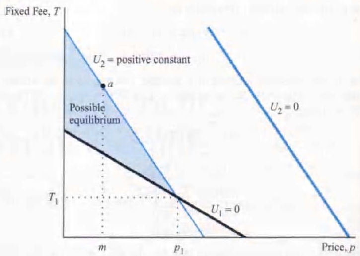

# Nonlinear Pricing with an Example

- These insights help solve the problem.
- First, the utility of consumer 1 is zero in the optimal solution so that $T_1=S_1(p)$
- Second, the utility of consumer 2 at ($T_1, p_1$) must equal its utility at ($T_2, p_2$). $\begin{matrix} S_1(p_1)-T_1 & = & 0 \\ S_2(p_1)-T_1 & = & S_2(p_2)-T_2 \end{matrix}$

# Nonlinear Pricing with an Example

- We can substitute $T_1$ and $T_2$ in terms of $p_1$ and $p_2$ to reexpress the problem facing the firm as: $\begin{matrix} \max_{p_1,p_2} & S_1(p_1)+(p_1-m)q_1(p_1)+S_2(p_2) \\ & -S_2(p_1)+S_1(p_1)+(p_2-m)q_2(p_2) \end{matrix}$
- By assumption, for any p, $q_2(p)=\lambda q_1(p)$
- And therefore, $S_2(p)=\lambda S_1(p)$

# Nonlinear Pricing with an Example

- As a result, we can rewrite equation as: $\begin{matrix} \max_{p_1,p_2} & S_1(p_1)+(p_1-m)q_1(p_1)+\lambda S_1(p_2) \\ & -\lambda S_1(p_1)+S_1(p_1)+\lambda(p_2-m)q_2(p_2) \\ = & (2-\lambda)S_1(p_1)+SP(p_1)+\lambda S_1(p_2)+\lambda SP(p_2) \end{matrix}$ where $SP(p_i)=(p_i-m)q_1(p_i)$ is the standard profit that a single price monopoly facing demand curve $q_1(p_i)$ earns at price $p_i$.
- We are now ready to determine the $p_1$ and $p_2$ that maximize equation.

# Nonlinear Pricing with an Example

- FOC: $\begin{matrix} (2-\lambda)\frac{dS_1(p_1)}{dp_1}+\frac{dSP(p_1)}{dp_1} & = & 0 \\ \frac{dS_1(p_2)}{dp_2}+\frac{dSP(p_2)}{dp_2} & = & 0 \end{matrix}$
- Because $dS_1/dp_1=-q_1(p_1)$ and $dS_1/dp_2=-q_1(p_2)$, we can rewrite equations as: $\begin{matrix} \frac{dSP(p_1)}{dp_1} & = & (2-\lambda)q_1(p_1) \\ \frac{dSP(p_2)}{dp_2} & = & q_1(p_2) \end{matrix}$

# Nonlinear Pricing with an Example

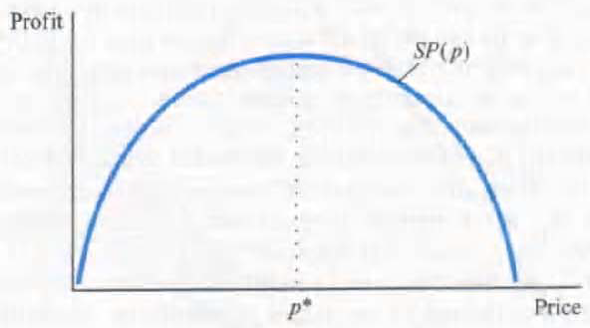

# Nonlinear Pricing with an Example

- If $\lambda>2$, the optimal p1 is such that the slope of $SP(p_1)$ is negative; that is $p_1>p^*$. $p_2$ should be chosen where the slope of SP(p) is positive; hence $p_2<p^*$.
- When $1<\lambda<2$, at $p_1$, the slope of SP(p) is positive so that $p_1<p^*$.
- In summary, the optimal tariff depends on how large $\lambda$ is.

# Tie-in Sales

# Tie-in Sales

- A tie-in sale is one in which a consumer can buy one good only by purchasing another good as well.
- Tie-in sales may be used to price discriminate.
- We use the term price discrimination quite broadly, in the sense that a tie-in sale enables a monopoly to increase its profit over and above what it would earn.

# Tie-in Sales

- Tie-in sales may be used to increase efficiency, avoid price regulations, give secret price discount, and to assure quality.
- **Efficiency**. For example, laced shoes are typically sold with laces; everyone who buys laced shoes needs shoe laces.
- Another efficiency justification for tie-in sales is that they economize on the cost of grading individual units of a product.

# Tie-in Sales

- **Evade Regulations**. Another common reason for tie-in sales is to evade price controls.
- A variant of the preceding example is to use a tie-in sale to circumvent regulation.

# Tie-in Sales

- **Secret price discounts**. Another motivation for tie-ins to give a secret price discount.
- For example, a member of an oligopoly may want to give price discounts without rivals knowing about them.
- It may be able to keep its discounts secret by selling a product at the oligopoly price but tying that sale to another product with a very low price.

# Tie-in Sales

- **Assure quality**. Tie-in sales can assure quality.
- For example, Kodak claimed that it tied the development of its film to its film sales because it did not believe that independent developers could develop Kodak film as skillfully as could Kodak.
- Generally, a firm may assure quality by forcing customers to buy another of its product or services or to not use substitutes.

# Tie-in Sales

- **Tie-in sales as a method of price discrimination**. A final reason for tie-in sales is to increase monopoly profit.
- There are two common types of tie-in sales.
- One is **bundling** or a **package tie-in sale** and occurs when two or more products are sold only in fixed proportions.

# Tie-in Sales

- The other common type is a **requirements tie-in sale**, where customers who purchase one product from a firm are required to make all their purchases of another product from that firm.
- As with all methods of nonlinear pricing in which different consumers pay different prices for the same product, a firm can use a tie-in sale to price discriminate only if trades between consumers are prevented.

# Tie-in Sales

- To examine package tie-in sales of independent products, we first suppose that a firm has a monopoly in both products.
- Then we examine a firm that has a monopoly in only one of the two products.

# Tie-in Sales

- Suppose a firm has a monopoly in both product A and product B.
- The monopoly sells to two types of consumers.
- Suppose the cost of producing the products is zero, and the monopoly wants to maximize the revenues that it receives from selling to these two types of consumers.

# Tie-in Sales

| - | Type 1 Consumers | Type 2 Consumers |
| --- | --- | --- |
| Amount($) willing to pay for A | 9000 | 10000 |
| Amount($) willing to pay for B | 3000 | 2000 |
| Amount($) willing to pay for A and B together | 12000 | 12000 |

# Tie-in Sales

- By changing the numbers in the table, it is possible to show that a tie-in is not always the most profitable strategy.

| - | Type 1 Consumers | Type 2 Consumers |
| --- | --- | --- |
| Amount($) willing to pay for A | 9000 | 10000 |
| Amount($) willing to pay for B | 500 | 2000 |
| Amount($) willing to pay for A and B together | 9500 | 12000 |

# Tie-in Sales

- In the absence of a resale market, a package tie-in resulted in a successful price discrimination because there is a negative relationship between what each type consumer is willing to pay for the two items.

# Tie-in Sales

- Some firms give consumers a choice between buying a bundle and buying goods separately, which is called *mixed bundling*.
- If you ran a restaurant, you would want to know which of the following pricing methods would maximize your profit:

# Tie-in Sales

- *Individual pricing*: Customers order each item separately off an a la carte menu.
- *Pure bundling*: Customers can only purchase a fixed-price meal—a bundle—that includes all courses and offers limited choices for each course.
- *Mixed bundling*: Customers may either order a fixed-price meal or order from an a la carte menu.

# Tie-in Sales

- You’d first have to determine whether you can bundle at all.
- If you can bundle, then you’d have to determine which pricing method gives you the highest profit.
- You can profitably bundle only if conditions on market power, resale, and tastes are met.

# Tie-in Sales

- For simplicity, suppose your restaurant only sells a main dish of halibut and a piece of pie for dessert.

# Tie-in Sales

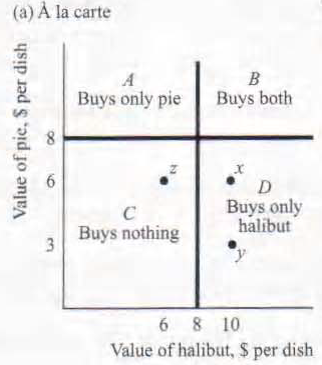

# Tie-in Sales

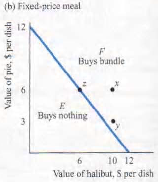

# Tie-in Sales

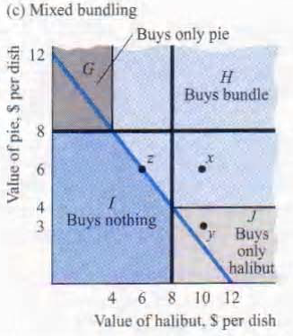

# Tie-in Sales

- Which pricing scheme gives you the highest profit depends on both how much your various customers are willing to pay for the two dishes and your costs of producing these dishes.
- For pure and mixed bundling to pay, your restaurant must sell more food than with individual pricing.
- Selling more, however, will increase profits only if revenue rises by more than costs

# Tie-in Sales

- Suppose you have only three types of customers—a, b, and c, with valuations of the two dishes in the following figure, and that your cost of producing a dish is $3 for halibut and $2 for pie.

# Tie-in Sales

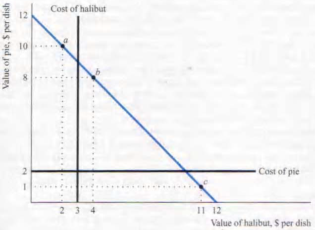

# Tie-in Sales

- If you price each dish separately, you maximize your profit by charging $11 for the halibut and $8 for pie.
- If you only sell a pure bundle, you charge $12.
- Using mixed bundling, you can set the bundle price at $12, the price of halibut at $10.99, and the price of pie at $9.99.

# Tie-in Sales

- You sell more dishes with pure bundling than with mixed bundling.
- The reason your profit is lower with pure bundling is that you’re selling dishes to customers who value those dishes at less than your cost of production.
- With these same customers, if you had no cost of production, you want to sell lots of dishes.

# Tie-in Sales

- Now suppose that the firm is a monopoly of only product A.
- Product B is competitively produced and sold at m.
- Before analyzing this example in detail, let us use common sense to guess the answer.

# Tie-in Sales

- Suppose there is no MC of production of A.
- A monopoly of product A uses a package tie-in and requires that for every unit of A purchased, one unit of product B must also be purchased.
- The monopoly charges p* for the package.

# Tie-in Sales

- The profit for every package sold is therefore $p^*-m$.
- This tie is not profitable if the monopoly would make more money if it sold product A separately and charged $p^*-m$.

# Tie-in Sales

- Two types of consumers consider purchasing the product.
- One type likes product B.
- If those consumers do not obtain product B in the package with product A, they buy it elsewhere at price m.

# Tie-in Sales

- The second type of consumer values a unit of B at less than m.
- If they buy the package, they are forced to consume more of product B than they would have if they had been allowed to buy B separately at the market price.
- These consumers will purchase the package consisting of A and B at $p^*$ only if they value A more than $p^*-m$.

# Tie-in Sales

- If A were sold by itself for $p^*-m$, more of this second type of consumer would purchase product A than are willing to purchase the package at $p^*$.
- Thus, a monopoly does not have an incentive to package its product in fixed proportions with a good that is competitively produced if the goods are independently demanded.

# Tie-in Sales

- Very often the demands for goods are interrelated.
- For example, the value of a camera depends on the availability of film.
- Let us first examine profit maximization with interrelated demands without tie-in sales.

# Tie-in Sales

- Suppose a firm has a monopoly in two products, A and B.
- The constant MC of production for A and B are $m_A$ and $m_B$, the corresponding prices are $p_A$ and $p_B$, and the corresponding demand curves are $D_A(p_A, p_B)$ and $D_B(p_A, p_B)$.

# Tie-in Sales

- The profit from selling A is: $\pi_A(p_A,p_B)=(p_A-m_A)D_A(p_A,p_B)$
- Similarly, the profit from selling B is: $\pi_B(p_A,p_B)=(p_B-m_B)D_B(p_A,p_B)$
- The monopoly’s problem is to maximize profits from its sales of the two products, $p_i$, which depend on the two prices: $\begin{matrix} \pi(p_A,p_B) & = & \pi_A(p_A,p_B)+\pi_B(p_A,p_B) \\ & = & (p_A-m_A)D_A(p_A,p_B)+(p_B-m_B)D_B(p_A,p_B) \end{matrix}$

# Tie-in Sales

- In choosing the optimal prices to charge, the monopoly not only considers its profits from the production and sale of A, but also takes into account how the price of A affects the profit from B and vice versa.

# Tie-in Sales

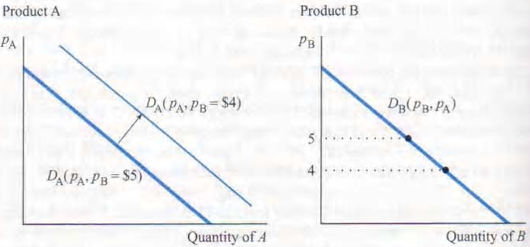

# Tie-in Sales

- If demands are interrelated, package tie-ins are one method that a monopoly can use to avoid inefficient behavior by consumers and hence increase its profit.
- Of course, as with all tie-in sales, if the tie-in is to work, is must be impossible for the consumer be able to undo the package tie-in.

# Tie-in Sales

- Perhaps the most common type of tie-in is a requirement tie-in in which consumers buy one good and are then required to make all their purchases of some other good from the same manufacturer.
- In the typical requirements tie, the firm sets a price for the first good and charges a high price for the related good.

# Quality Choice

# Quality Choice

- Imagine a monopoly that produces several goods of differing quality.
- The monopoly’s decisions about levels of quality are influenced by the same forces that influence the choice of nonlinear pricing schemes.
- In summary, when consumers prefer different levels of quality, a monopoly manipulates the qualities of goods produced in the market in order to extract CS.

# Other Methods of Nonlinear Pricing

# Other Methods of Nonlinear Pricing

- **Minimum Quantities and Quantity Discount**. Many sellers specify that their product can be bought only in certain minimum amounts.
- **Selection of Price Schedules**. Sometimes consumers must choose the pricing schedule that will govern their purchases before they know how much they will purchase.

# Other Methods of Nonlinear Pricing

- **Premium for Priority**. If consumers differ in their desires to obtain a good quickly, a firm can charge more for rapid delivery.
- **Auctions**. Some firms use auctions to sell valuable assets. The purpose of an auction is to obtain the maximum revenue from buyers when the seller does not know which buyer value the goods the most.